# An Introduction to Statistical Learning

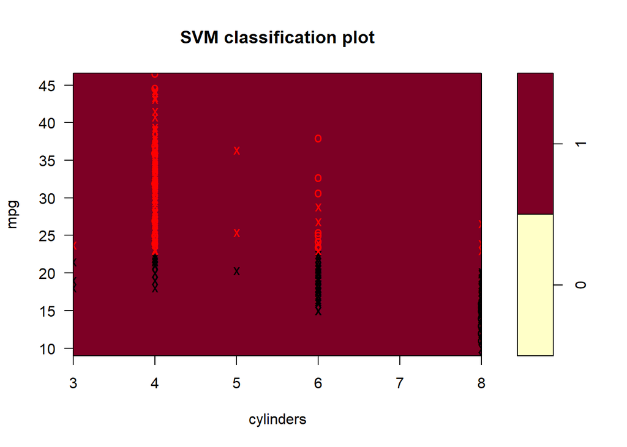

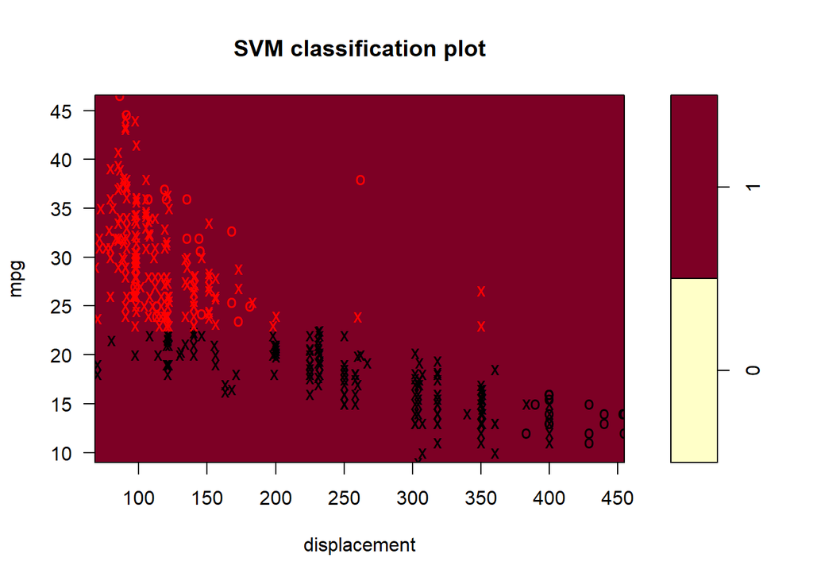

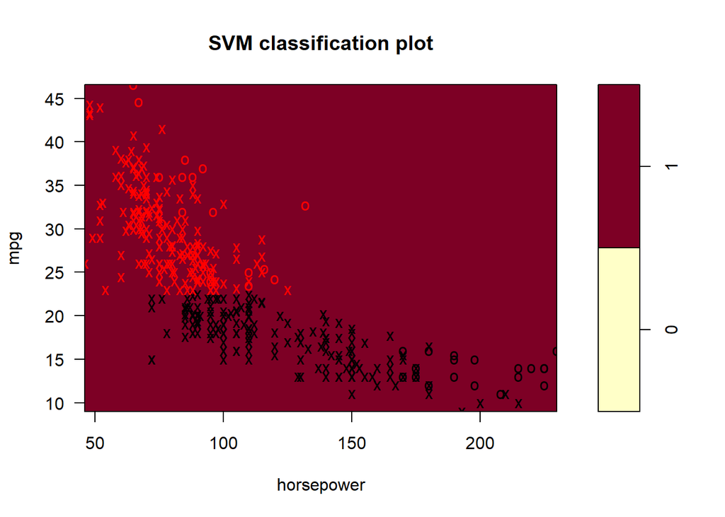

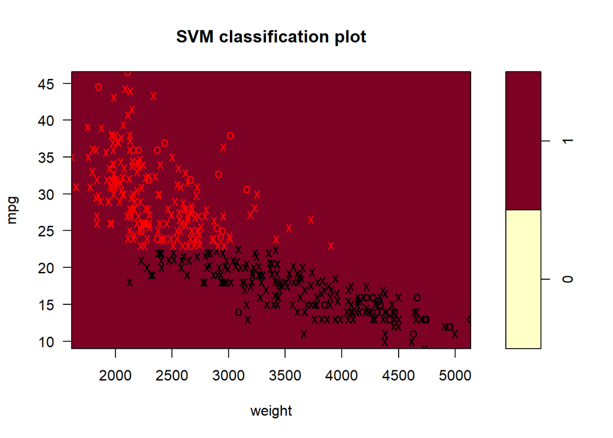

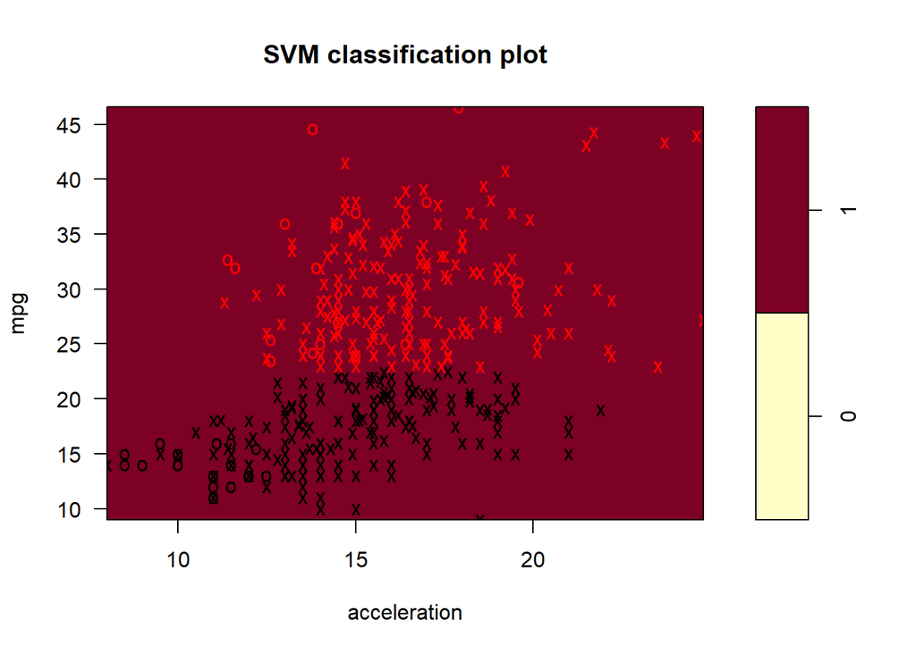

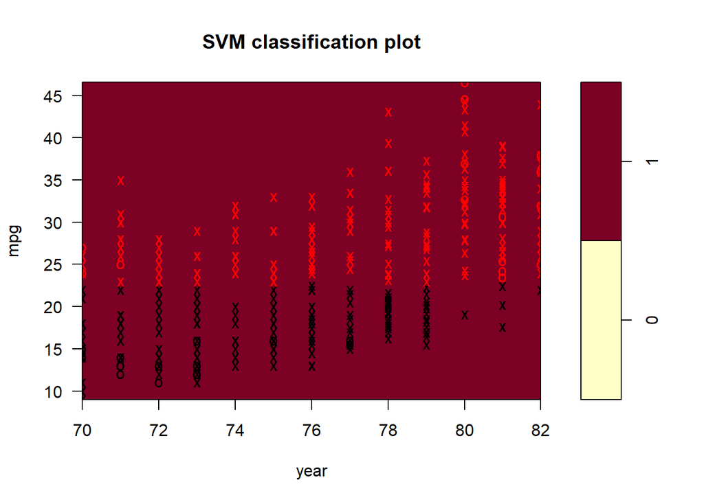

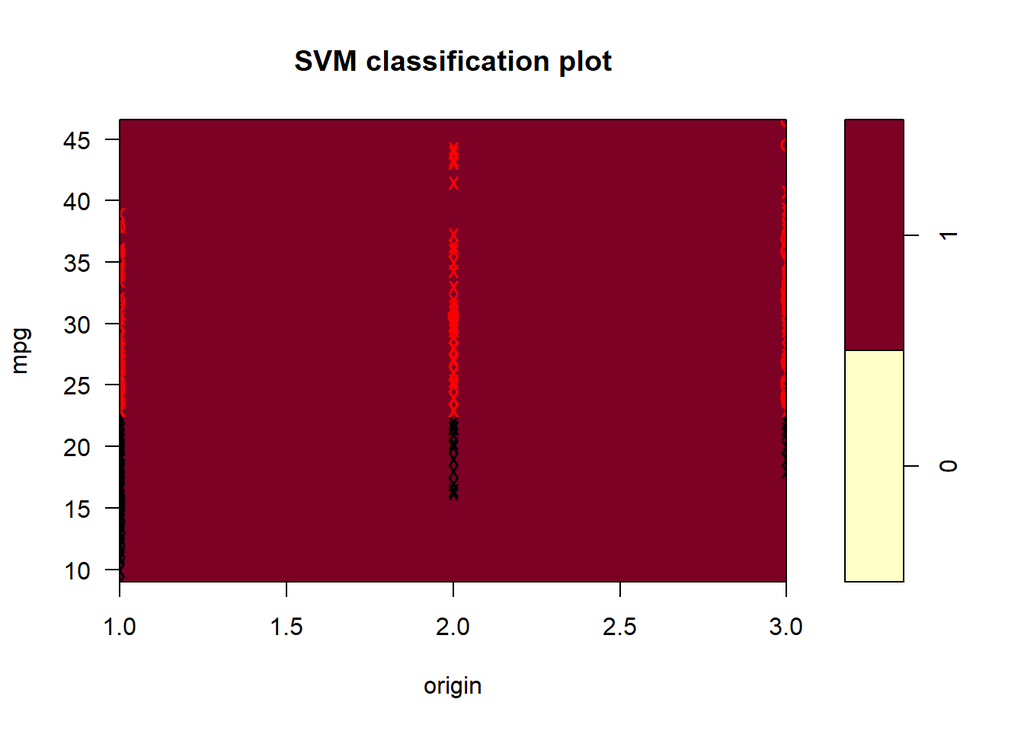

```r
plotpairs(svm.poly)
```

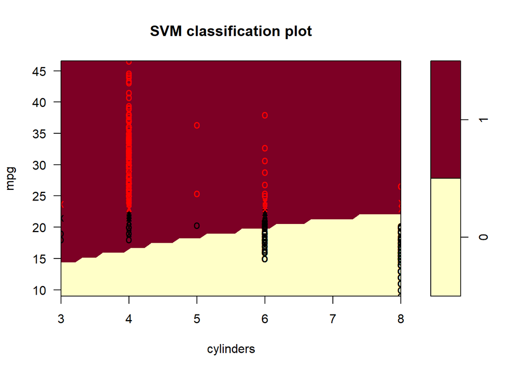

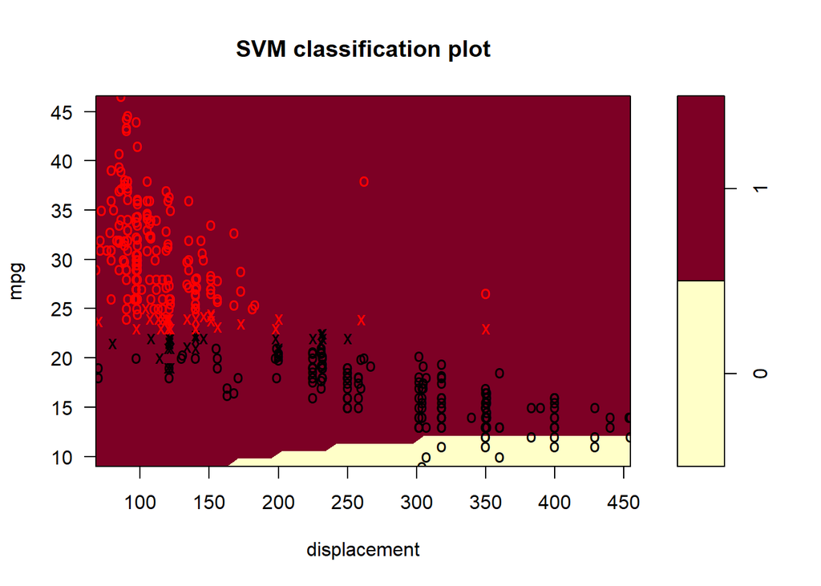

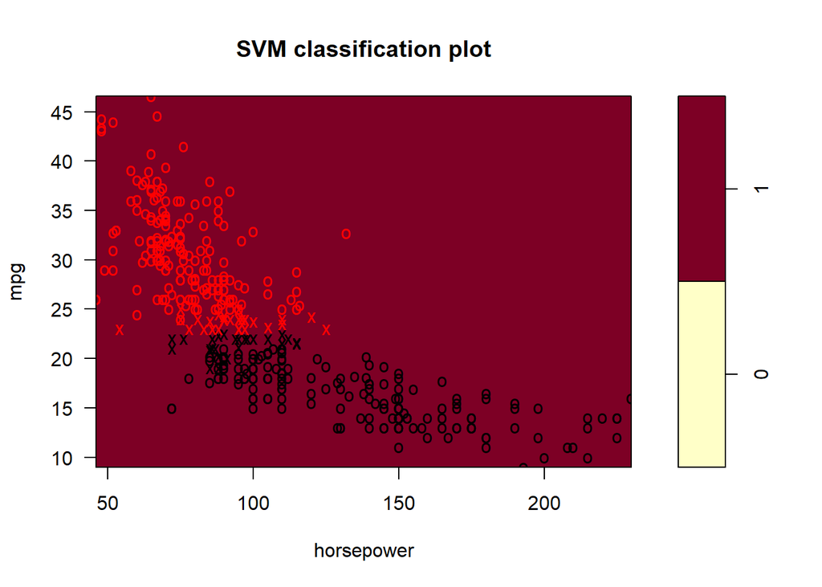

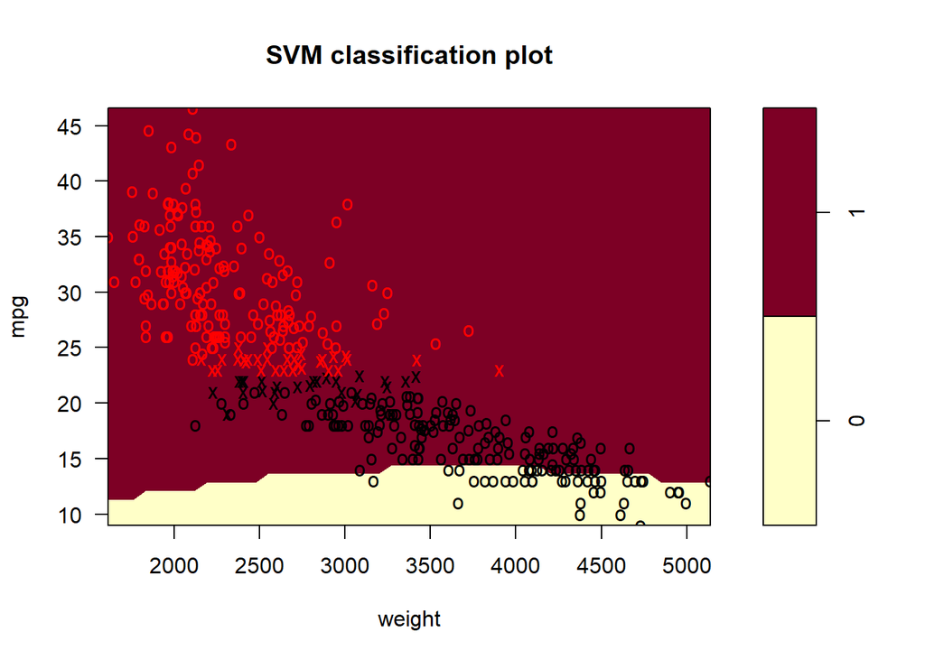

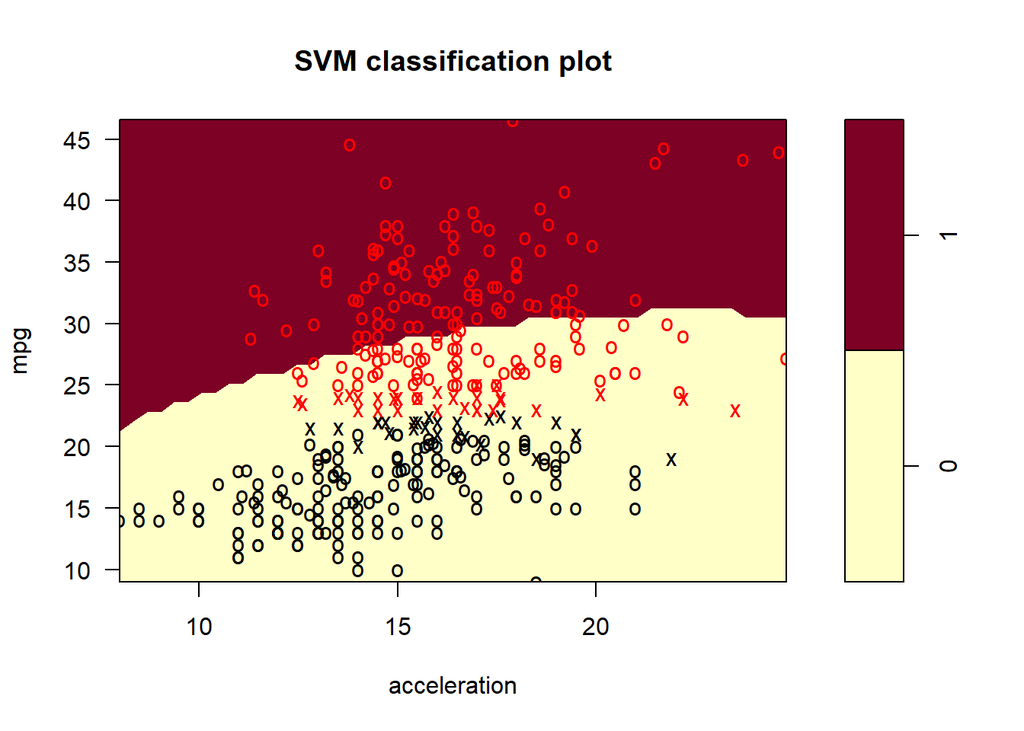

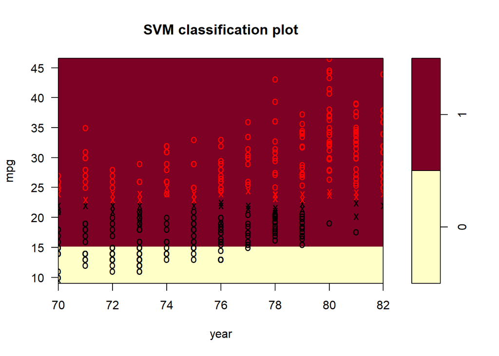

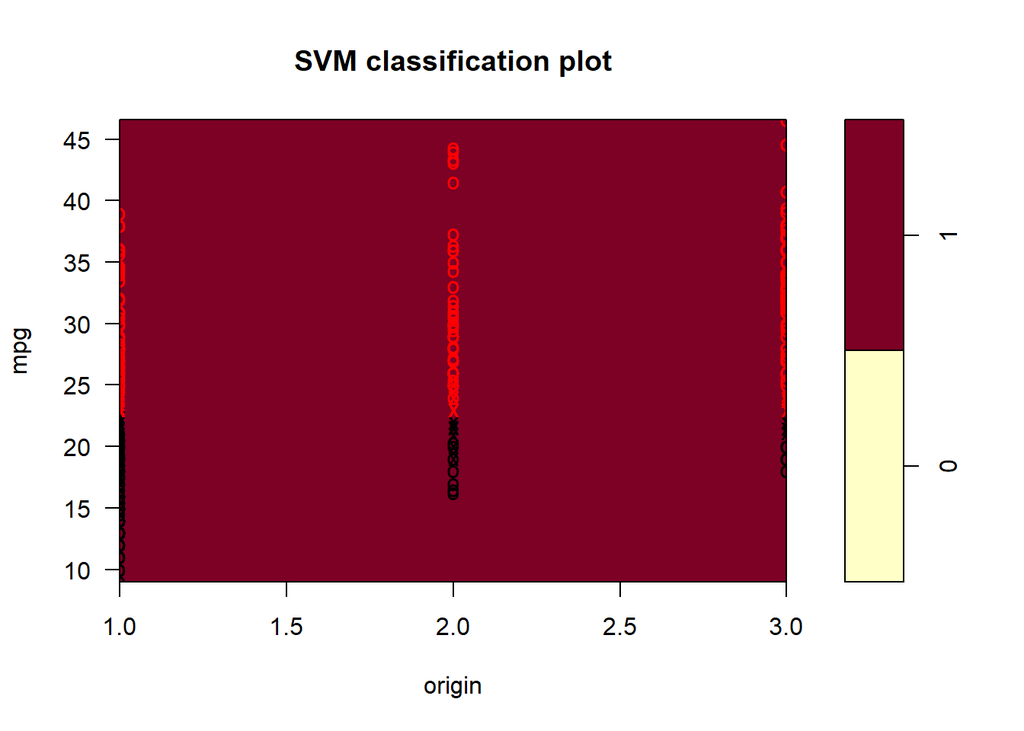

```r
plotpairs(svm.radial)
```

#### **8.** This problem involves the OJ data set which is part of the ISLR package.

1. Create a training set containing a random sample of 800 observations, and a test set containing the remaining observations.

```r
library(ISLR)
set.seed(1)
train = sample(nrow(OJ), 800)
oj.train = OJ[train, ]
oj.test = OJ[-train, ]
```

2. Fit a support vector classifier to the training data using cost=0.01, with Purchase as the response and the other variables as predictors. Use the summary() function to produce summary statistics, and describe the results obtained.

```r
svm.linear = svm(Purchase~., data=oj.train, kernel="linear", cost = 0.01)
summary(svm.linear)
```

```
##
## Call:
## svm(formula = Purchase ~ ., data = oj.train, kernel = "linear", cost = 0.01)
##
##
## Parameters:
##    SVM-Type:  C-classification
##  SVM-Kernel:  linear
##        cost:  0.01
##
## Number of Support Vectors:  435
##
##  ( 219 216 )
##
##
## Number of Classes:  2
##
## Levels:
##  CH MM
```

- the SVM creates 435 support vectors of which 219 belong to CH and 216 belong to MM
3. What are the training and test error rates?

```r
train.pred = predict(svm.linear, oj.train)
table(oj.train$Purchase, train.pred)
```

```
##     train.pred
##       CH  MM
##   CH 420  65
##   MM  75 240
```

```r
(75 + 65) / (420 + 240 + 75 + 65)
```

```
## [1] 0.175
```

```r
test.pred = predict(svm.linear, oj.test)
table(oj.test$Purchase, test.pred)
```

```
##     test.pred
##       CH  MM
##   CH 153  15
##   MM  33  69
```

```r
(33 + 15) / (153 + 69 + 15 + 33)
```

```
## [1] 0.1777778
```

4. Use the tune() function to select an optimal cost. Consider values in the range 0.01 to 10

```r
set.seed(1)
tune.out = tune(svm, Purchase ~ ., data = oj.train, kernel = "linear", ranges = list(cost = c(0.01, 0.05, 0.1, 0.5, 1, 5, 10)))
summary(tune.out)
```

```
##
## Parameter tuning of 'svm':
##
## - sampling method: 10-fold cross validation
##
## - best parameters:
##  cost
##   0.5
##
## - best performance: 0.16875
##
## - Detailed performance results:
##    cost   error dispersion
## 1  0.01 0.17625 0.02853482
## 2  0.05 0.17625 0.02853482
## 3  0.10 0.17250 0.03162278
## 4  0.50 0.16875 0.02651650
## 5  1.00 0.17500 0.02946278
## 6  5.00 0.17250 0.03162278
## 7 10.00 0.17375 0.03197764
```

5. Compute the training and test error rates using this new value for cost.

```r
svm.linear = svm(Purchase ~ ., kernel = "linear", data = oj.train, cost = tune.out$best.parameter$cost)
train.pred = predict(svm.linear, oj.train)
table(oj.train$Purchase, train.pred)
```

```
##     train.pred
##       CH  MM
##   CH 424  61
##   MM  71 244
```

```r
(71 + 61) / (242 + 244 + 61 +71 )
```

[output not shown]

```r
test.pred = predict(svm.linear, oj.test)
table(oj.test$Purchase, test.pred)
```

```
##     test.pred
##       CH  MM
##   CH 155  13
##   MM  29  73
```

```r
(29+13)/(155+73+13+29)
```

```
## [1] 0.1555556
```

6. Repeat parts (b) through (e) using a support vector machine with a radial kernel. Use the default value.

```r
set.seed(1)
tune.out = tune(svm, Purchase ~ ., data = oj.train, kernel = "radial", ranges = list(cost = c(0.01, 0.05, 0.1, 0.5, 1, 5, 10)))
summary(tune.out)
```

```
##
## Parameter tuning of 'svm':
##
## - sampling method: 10-fold cross validation
##
## - best parameters:
##  cost
##   0.5
##
## - best performance: 0.1675
##
## - Detailed performance results:
##    cost   error dispersion
## 1  0.01 0.39375 0.04007372
## 2  0.05 0.20250 0.03374743
## 3  0.10 0.18625 0.02853482
## 4  0.50 0.16750 0.02443813
## 5  1.00 0.17125 0.02128673
## 6  5.00 0.18000 0.02220485
## 7 10.00 0.18625 0.02853482
```

```r
svm.radial = svm(Purchase ~ ., kernel = "radial", data = oj.train, cost = tune.out$best.parameter$cost)
train.pred = predict(svm.radial, oj.train)
table(oj.train$Purchase, train.pred)
```

```
##     train.pred
##       CH  MM
##   CH 438  47
##   MM  71 244
```

```r
(47+71)/(438+71+47+244)
```

```
## [1] 0.1475
```

```r
test.pred = predict(svm.radial, oj.test)
table(oj.test$Purchase, test.pred)
```

```
##     test.pred
##       CH  MM
##   CH 150  18
##   MM  30  72
```

```r
(18+30)/(150+18+30+72)
```

```
## [1] 0.1777778
```

```r
set.seed(1)
tune.out = tune(svm, Purchase ~ ., data = oj.train, kernel = "poly", ranges = list(cost = c(0.01, 0.05, 0.1, 0.5, 1, 5, 10)), degree = 2)
summary(tune.out)
```

```
##
## Parameter tuning of 'svm':
##
## - sampling method: 10-fold cross validation
##
## - best parameters:
##  cost
##    10
##
## - best performance: 0.18125
##
## - Detailed performance results:
##    cost   error dispersion
## 1  0.01 0.39125 0.04210189
## 2  0.05 0.34875 0.04348132
## 3  0.10 0.32125 0.05001736
## 4  0.50 0.20625 0.04050463
## 5  1.00 0.20250 0.04116363
## 6  5.00 0.18250 0.03496029
## 7 10.00 0.18125 0.02779513
```

```r
svm.poly = svm(Purchase ~ ., kernel = "poly", data = oj.train, cost = tune.out$best.parameter$cost)
train.pred = predict(svm.poly, oj.train)
table(oj.train$Purchase, train.pred)
```

```
##     train.pred
##       CH  MM
##   CH 446  39
##   MM  75 240
```

```r
(39+75)/(446+39+75+240)
```

```
## [1] 0.1425
```

```r
test.pred = predict(svm.poly, oj.test)
table(oj.test$Purchase, test.pred)
```

```
##     test.pred
##       CH  MM
##   CH 155  13
##   MM  42  60
```

```r
(13+42)/(155+13+42+60)
```

```
## [1] 0.2037037
```